# Sprint 1: Tasca M1 T01

## Exercici 1

#### A partir dels documents adjunts (estructura i dades), crea una base de dades amb MySQL.

#### Mostra les característiques principals de l'esquema creat i explica les diferents taules i variables que hi ha.

#### A) Características principales del Esquema

La Base de Datos "Movies" consta de cinco tablas, con los campos siguientes:

- tb_genre:

  ```
        1- genre_id: Índice del género de la película (*) (1,2,3....)
        2- genre_name: Tipo de género de la película. (1. Acción, 2. Ciencia Ficción, 3. Comedia,etc..)
        3- created_by_user: Creador de la tabla
        4- created_date: Fecha de creación
        5- update_date: Fecha grabación
  ```

- tb_movie:

  ```
        1- movie_id: Índice de peliculas (**) (1,2,3...)
        2- movie_title: Título de la película
        3- movie_date: Fecha de la película
        4- movie_format: formato de la película. (Film ó Digital)
        5- movie_genre_id: código del género de la película (*) (1, 2, 3....)
        6- created_by_user: Creador de la tabla
        7- created_date: Fecha de creación
        8- update_date: Fecha grabació
  ```

- tb_movie_person:

  ```
        1- movie_id: Índice de peliculas (**)
        2- person_id: Índice de personas (***)
        3- role_id: Índice de roles (****) (1 a 5)
        4- movie_award_ind: premios
        5- created_by_user: Creador de la tabla
        6- created_date: Fecha de creación
        7- update_date: Fecha grabación
  ```

- tb_person:

  ```
        1- person_id:Índice de persona (***) (1,2,3...)
        2- person_name: Nombre de la persona
        3- person_country: nacionalidad
        4- person_dob: fecha de nacimiento
        5- person_dod: fecha de fallecimiento
        6- person_parent_id: Índice de parent
        7- created_by_user: Creador de la tabla
        8- created_date: Fecha de creación
        9- update_date: Fecha grabación
  ```

- tb_role:

  ```
        1- role_id: Índice de roles (****) (1 a 5)
        2- role_name: nombre de los roles (1. Actor, 2. Director, 3. Productor, 4. Guionista y 5. Música)
        3- created_by_user: Creador de la tabla
        4- created_date: Fecha de creación
        5- update_date: Fecha grabación
  ```

(*....) Los asteríscos indican las relaciones de dependencia entre las diferentes tablas de la base de datos

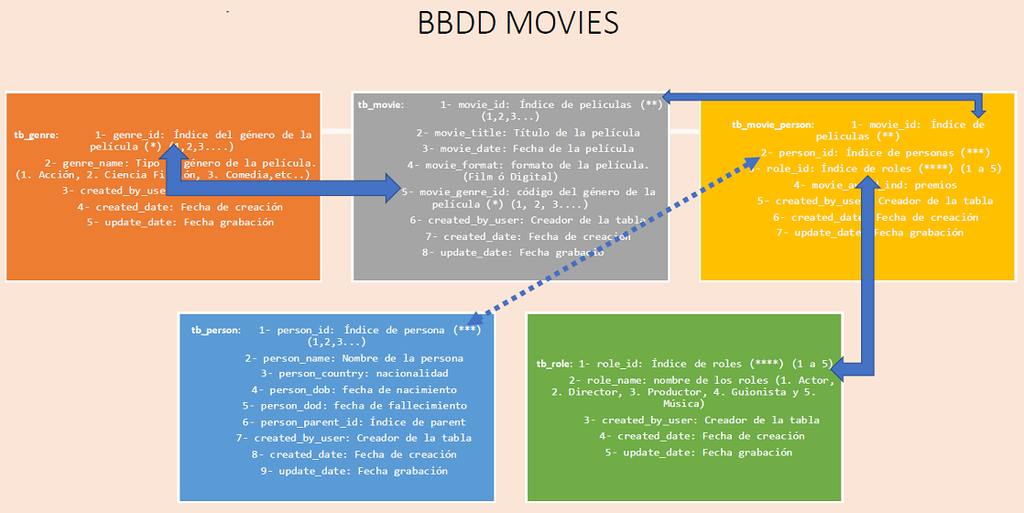

#### B) Capturas de Pantallas de las diferentes tablas y datos de Movies

#### B.1) Tabla de Géneros: Tabla_tb_genre

[figure not shown]

#### B.1.1) Tabla de Géneros: Datos_tb_genre

[figure not shown]

#### B.1.2) Tabla de Géneros: Dades a introduir.txt_tb_genre

[figure not shown]

#### B.2) Tabla de películass: Tabla_tb_movie

[figure not shown]

#### B.3) Tabla de películas y Personas: Tabla_tb_movie_person

[figure not shown]

#### B.4) Tabla de Personas: Tabla_tb_person

[figure not shown]

#### B.5) Tabla de Roles: Tabla_tb_role

[figure not shown]

#### C) Conexión MSQL - Python

```python
import mysql.connector
import pandas as pd
import sqlalchemy

# Configuración warnings
# ==============================================================================
import warnings
warnings.filterwarnings('ignore')
```

```python
mydb = mysql.connector.connect(
  host="localhost",
  user="root",
  password="hectorete1"
)

print(mydb)
```

```
<mysql.connector.connection_cext.CMySQLConnection object at 0x000001F76DBE5EB0>
```

#### C.1) Tabla de Géneros de Películas

```python
engine = sqlalchemy.create_engine('mysql+mysqlconnector://root:hectorete1@localhost/movies')
data_genre = pd.read_sql_table("tb_genre", engine)
# check first rows of thcursor=connection.cursor()is table
data_genre
```

|  | genre_id | genre_name | created_by_user | created_date | updated_date |
| --- | --- | --- | --- | --- | --- |
| 0 | 1 | Acción | OS_SGAD | NaT | NaT |
| 1 | 2 | Ciencia Ficción | OS_SGAD | NaT | NaT |
| 2 | 3 | Comedia | OS_SGAD | NaT | NaT |
| 3 | 4 | Drama | OS_SGAD | NaT | NaT |
| 4 | 5 | Fantasía | apermag | NaT | NaT |
| 5 | 6 | Melodrama | apermag | 2018-09-01 | 2018-09-27 |
| 6 | 7 | Musical | OS_SGAD | NaT | NaT |
| 7 | 8 | Romance | OS_SGAD | NaT | NaT |
| 8 | 9 | Suspense | OS_SGAD | NaT | NaT |
| 9 | 10 | Terror | OS_SGAD | NaT | NaT |
| 10 | 11 | Bélico | OS_SGAD | NaT | NaT |
| 11 | 69 | Documental | OS_SGAD | NaT | NaT |

#### C.2) Tabla de Películas

```python
data_movie = pd.read_sql_table("tb_movie", engine)
# check first rows of this table
data_movie
```

|  | movie_id | movie_title | movie_date | movie_format | movie_genre_id | created_by_user | created_date | updated_date |
| --- | --- | --- | --- | --- | --- | --- | --- | --- |
| 0 | 1 | Apocalypse Now | 1979-05-10 | Film | 11 | OS_SGAD | 2022-07-15 | NaT |
| 1 | 2 | Star Wars:Episode IV - A New Hope | 1977-05-25 | Film | 2 | OS_SGAD | 2022-07-15 | NaT |
| 2 | 3 | Indiana Jones and the Temple of Doom | 1984-05-08 | Film | 2 | OS_SGAD | NaT | NaT |
| 3 | 4 | The Terminal | 2004-06-18 | Digital | 3 | OS_SGAD | NaT | NaT |
| 4 | 5 | Jaws | 1975-01-01 | Film | 10 | OS_SGAD | NaT | NaT |
| 5 | 6 | ET The Extraterrestrial | 1982-07-25 | Film | 5 | OS_SGAD | NaT | NaT |
| 6 | 7 | Psycho | 1960-05-06 | Film | 9 | OS_SGAD | NaT | NaT |
| 7 | 8 | Ocho Apellidos Vascos | 2014-03-14 | Digital | 3 | OS_SGAD | NaT | NaT |
| 8 | 9 | Ocho Apellidos Catalanes | 2016-06-09 | Digital | 3 | OS_SGAD | NaT | NaT |
| 9 | 10 | El otro lado de la cama | 2002-09-04 | Digital | 8 | OS_SGAD | NaT | NaT |
| 10 | 12 | El dia de la bestia | 1994-12-25 | Film | 2 | OS_SGAD | NaT | NaT |
| 11 | 13 | Braveheart | 1995-08-08 | Film | 4 | OS_SGAD | NaT | NaT |
| 12 | 14 | The Shawshank Redemption | 1992-01-07 | Film | 4 | OS_SGAD | NaT | NaT |
| 13 | 15 | Las brujas de Zugarramurdi | 2009-10-07 | Digital | 9 | OS_SGAD | NaT | NaT |
| 14 | 16 | Blade Runner | 1982-12-25 | Digital | 2 | OS_SGAD | NaT | NaT |

#### C.3) Tabla de ID ( Películas - Personas - Roles)

```python
data_movie_person = pd.read_sql_table("tb_movie_person", engine)
# check first rows of this table
data_movie_person
```

|  | movie_id | person_id | role_id | movie_award_ind | created_by_user | created_date | updated_date |
| --- | --- | --- | --- | --- | --- | --- | --- |
| 0 | 1 | 1 | 2 | Y | OS_SGAD | NaT | NaT |
| 1 | 1 | 1 | 3 | N | OS_SGAD | NaT | NaT |
| 2 | 1 | 1 | 5 | N | OS_SGAD | NaT | NaT |
| 3 | 1 | 2 | 5 | N | OS_SGAD | NaT | NaT |
| 4 | 1 | 3 | 1 | N | OS_SGAD | NaT | NaT |
| 5 | 1 | 4 | 1 | N | OS_SGAD | NaT | NaT |
| 6 | 1 | 5 | 1 | Y | OS_SGAD | NaT | NaT |
| 7 | 1 | 6 | 1 | N | OS_SGAD | NaT | NaT |
| 8 | 1 | 41 | 1 | N | OS_SGAD | NaT | NaT |
| 9 | 2 | 6 | 1 | N | OS_SGAD | NaT | NaT |
| 10 | 2 | 7 | 2 | Y | OS_SGAD | NaT | NaT |
| 11 | 2 | 8 | 3 | N | OS_SGAD | NaT | NaT |
| 12 | 3 | 6 | 1 | N | OS_SGAD | NaT | NaT |
| 13 | 3 | 7 | 1 | N | OS_SGAD | NaT | NaT |
| 14 | 3 | 7 | 4 | N | OS_SGAD | NaT | NaT |
| 15 | 3 | 9 | 2 | N | OS_SGAD | NaT | NaT |
| 16 | 3 | 10 | 5 | N | OS_SGAD | NaT | NaT |
| 17 | 4 | 9 | 2 | N | OS_SGAD | NaT | NaT |
| 18 | 4 | 9 | 3 | N | OS_SGAD | NaT | NaT |
| 19 | 4 | 11 | 1 | N | OS_SGAD | NaT | NaT |
| 20 | 4 | 12 | 1 | N | OS_SGAD | NaT | NaT |
| 21 | 5 | 9 | 2 | N | OS_SGAD | NaT | NaT |
| 22 | 6 | 9 | 2 | N | OS_SGAD | NaT | NaT |
| 23 | 7 | 13 | 1 | N | OS_SGAD | NaT | NaT |
| 24 | 7 | 13 | 2 | N | OS_SGAD | NaT | NaT |
| 25 | 7 | 13 | 3 | N | OS_SGAD | NaT | NaT |
| 26 | 7 | 14 | 2 | N | OS_SGAD | NaT | NaT |
| 27 | 7 | 15 | 2 | N | OS_SGAD | NaT | NaT |
| 28 | 8 | 16 | 2 | N | OS_SGAD | NaT | NaT |
| 29 | 8 | 17 | 1 | N | OS_SGAD | NaT | NaT |
| 30 | 8 | 18 | 1 | N | OS_SGAD | NaT | NaT |
| 31 | 8 | 19 | 1 | N | OS_SGAD | NaT | NaT |
| 32 | 8 | 20 | 1 | N | OS_SGAD | NaT | NaT |
| 33 | 9 | 16 | 2 | N | OS_SGAD | NaT | NaT |
| 34 | 9 | 17 | 1 | N | OS_SGAD | NaT | NaT |
| 35 | 9 | 18 | 1 | N | OS_SGAD | NaT | NaT |
| 36 | 9 | 19 | 1 | N | OS_SGAD | NaT | NaT |
| 37 | 9 | 20 | 1 | N | OS_SGAD | NaT | NaT |
| 38 | 10 | 16 | 2 | N | OS_SGAD | NaT | NaT |
| 39 | 13 | 28 | 1 | Y | OS_SGAD | NaT | NaT |
| 40 | 13 | 28 | 2 | N | OS_SGAD | NaT | NaT |
| 41 | 14 | 29 | 1 | N | OS_SGAD | NaT | NaT |
| 42 | 14 | 30 | 1 | N | OS_SGAD | NaT | NaT |

#### C.4) Tabla de Personas

```python
data_person = pd.read_sql_table("tb_person", engine)
# check first rows of this table
data_person
```

|  | person_id | person_name | person_country | person_dob | person_dod | person_parent_id | created_by_user | created_date | updated_date |
| --- | --- | --- | --- | --- | --- | --- | --- | --- | --- |
| 0 | 1 | Francis Ford Coppola | United States | 1939-04-07 | NaT | NaN | OS_SGAD | NaT | NaT |
| 1 | 2 | Carmine Coppola | United States | 1945-07-08 | NaT | NaN | OS_SGAD | NaT | NaT |
| 2 | 3 | Marlon Brando | United States | 1924-04-03 | 2004-07-01 | NaN | OS_SGAD | NaT | NaT |
| 3 | 4 | Robert Duvall | United States | 1931-01-05 | NaT | NaN | OS_SGAD | NaT | NaT |
| 4 | 5 | Martin Sheen | United States | 1940-08-03 | NaT | NaN | OS_SGAD | NaT | NaT |
| 5 | 6 | Harrison Ford | United States | 1942-07-13 | NaT | NaN | OS_SGAD | NaT | NaT |
| 6 | 7 | George Lucas | United States | 1944-05-14 | NaT | NaN | OS_SGAD | NaT | NaT |
| 7 | 8 | Gary Kurtz | United States | 1940-07-27 | NaT | NaN | OS_SGAD | NaT | NaT |
| 8 | 9 | Steven Spielberg | United States | 1946-12-18 | NaT | NaN | OS_SGAD | NaT | NaT |
| 9 | 10 | John Williams | United States | 1928-08-08 | NaT | NaN | OS_SGAD | NaT | NaT |
| 10 | 11 | Tom Hanks | United States | 1956-07-09 | NaT | NaN | OS_SGAD | NaT | NaT |
| 11 | 12 | Catherine Zeta-Jones | Wales | 1969-09-25 | NaT | NaN | OS_SGAD | NaT | NaT |
| 12 | 13 | Alfred Joseph Hitchcock | United Kingdom | 1899-08-13 | 1980-04-29 | NaN | OS_SGAD | NaT | NaT |
| 13 | 14 | Anthony Perkins | United States | 1934-04-04 | 1992-09-08 | NaN | OS_SGAD | NaT | NaT |
| 14 | 15 | Vera Miles | United States | 1929-08-23 | NaT | NaN | OS_SGAD | NaT | NaT |
| 15 | 16 | Emilio Martinez Lazaro | Spain | 1956-09-09 | NaT | NaN | OS_SGAD | NaT | NaT |
| 16 | 17 | Dani Rovira | Spain | 1984-07-01 | NaT | NaN | OS_SGAD | NaT | NaT |
| 17 | 18 | Clara Lago | Spain | 1986-04-17 | NaT | NaN | OS_SGAD | NaT | NaT |
| 18 | 19 | Carmen Machi | Spain | 1964-08-09 | NaT | NaN | OS_SGAD | NaT | NaT |
| 19 | 20 | Karra Elejalde | Spain | 1960-03-06 | NaT | NaN | OS_SGAD | NaT | NaT |
| 20 | 21 | Daniel Sanchez Arevalo | Spain | 1970-06-08 | NaT | NaN | OS_SGAD | NaT | NaT |
| 21 | 22 | Quim Gutierrez | Spain | 1981-03-27 | NaT | NaN | OS_SGAD | NaT | NaT |
| 22 | 23 | Robert Alamo | Spain | 1970-05-06 | NaT | NaN | OS_SGAD | NaT | NaT |
| 23 | 24 | Hector Colome | Spain | 1944-10-25 | 2015-02-28 | NaN | OS_SGAD | NaT | NaT |
| 24 | 25 | Veronica Echegui | Spain | 1983-03-14 | NaT | NaN | OS_SGAD | NaT | NaT |
| 25 | 26 | Patrick Criado | Spain | 1995-09-23 | NaT | NaN | OS_SGAD | NaT | NaT |
| 26 | 27 | Sean Connery | Scotland | 1930-07-08 | NaT | NaN | OS_SGAD | NaT | NaT |
| 27 | 28 | Mel Gibson | Australia | 1950-08-09 | NaT | NaN | OS_SGAD | NaT | NaT |
| 28 | 29 | Morgan Freeman | United States | 1935-10-01 | NaT | NaN | OS_SGAD | NaT | NaT |
| 29 | 30 | Tim Robbins | United States | 1949-06-07 | NaT | NaN | OS_SGAD | NaT | NaT |
| 30 | 41 | Charlie Sheen | United States | 1965-09-03 | NaT | 5.0 | OS_SGAD | NaT | NaT |
| 31 | 42 | Emilio Estevez | United States | 1962-05-12 | NaT | 5.0 | OS_SGAD | NaT | NaT |
| 32 | 43 | Ramón Estevez | United States | 1963-08-07 | NaT | 5.0 | OS_SGAD | NaT | NaT |
| 33 | 44 | Reneé Estevez | United States | 1967-04-02 | NaT | 5.0 | OS_SGAD | NaT | NaT |
| 34 | 45 | Paula Speert Sheen | United States | 1986-01-06 | NaT | 41.0 | OS_SGAD | NaT | NaT |
| 35 | 46 | Bob Sheen | United States | 2009-05-01 | NaT | 41.0 | OS_SGAD | NaT | NaT |
| 36 | 47 | Max Sheen | United States | 2009-05-01 | NaT | 41.0 | OS_SGAD | NaT | NaT |
| 37 | 48 | Sam Sheen | United States | 2004-03-09 | NaT | 41.0 | OS_SGAD | NaT | NaT |
| 38 | 49 | Lola Sheen | United States | 2005-06-01 | NaT | 41.0 | OS_SGAD | NaT | NaT |
| 39 | 50 | Paula Jones-Sheen | United States | 2003-07-06 | NaT | 45.0 | OS_SGAD | NaT | NaT |
| 40 | 51 | Paloma Rae Estevez | United States | 1986-02-15 | NaT | 42.0 | OS_SGAD | NaT | NaT |
| 41 | 52 | Taylor Levi Estevez | United States | 1984-06-22 | NaT | 42.0 | OS_SGAD | NaT | NaT |

#### C.5) Tabla de Roles

```python
data_role = pd.read_sql_table("tb_role", engine)
# check first rows of this table
data_role
```

|  | role_id | role_name | created_by_user | created_date | updated_date |
| --- | --- | --- | --- | --- | --- |
| 0 | 1 | Actor | OS_SGAD | NaT | NaT |
| 1 | 2 | Director | OS_SGAD | NaT | NaT |
| 2 | 3 | Productor | OS_SGAD | NaT | NaT |
| 3 | 4 | Guionista | OS_SGAD | NaT | NaT |
| 4 | 5 | Música | OS_SGAD | NaT | NaT |

## Exercici 2

#### Realitza la següent consulta sobre la base de dades acabada de crear:

- Has d'obtenir el nom, el país i la data de naixement d'aquelles persones per les quals no consti una data de mort
- i ordenar les dades de la persona més vella a la persona més jove.

```python
query = '''
SELECT person_name, person_country, person_dob,
       timestampdiff(YEAR, person_dob, current_date) as current_ages
FROM tb_person
WHERE person_dod is null
ORDER BY current_ages desc;

'''

current_ages_df = pd.read_sql_query(query, engine)
current_ages_df
```

|  | person_name | person_country | person_dob | current_ages |
| --- | --- | --- | --- | --- |
| 0 | John Williams | United States | 1928-08-08 | 93 |
| 1 | Sean Connery | Scotland | 1930-07-08 | 92 |
| 2 | Vera Miles | United States | 1929-08-23 | 92 |
| 3 | Robert Duvall | United States | 1931-01-05 | 91 |
| 4 | Morgan Freeman | United States | 1935-10-01 | 86 |
| 5 | Francis Ford Coppola | United States | 1939-04-07 | 83 |
| 6 | Gary Kurtz | United States | 1940-07-27 | 82 |
| 7 | Martin Sheen | United States | 1940-08-03 | 81 |
| 8 | Harrison Ford | United States | 1942-07-13 | 80 |
| 9 | George Lucas | United States | 1944-05-14 | 78 |
| 10 | Carmine Coppola | United States | 1945-07-08 | 77 |
| 11 | Steven Spielberg | United States | 1946-12-18 | 75 |
| 12 | Tim Robbins | United States | 1949-06-07 | 73 |
| 13 | Mel Gibson | Australia | 1950-08-09 | 71 |
| 14 | Tom Hanks | United States | 1956-07-09 | 66 |
| 15 | Emilio Martinez Lazaro | Spain | 1956-09-09 | 65 |
| 16 | Karra Elejalde | Spain | 1960-03-06 | 62 |
| 17 | Emilio Estevez | United States | 1962-05-12 | 60 |
| 18 | Ramón Estevez | United States | 1963-08-07 | 58 |
| 19 | Carmen Machi | Spain | 1964-08-09 | 57 |
| 20 | Charlie Sheen | United States | 1965-09-03 | 56 |
| 21 | Reneé Estevez | United States | 1967-04-02 | 55 |
| 22 | Robert Alamo | Spain | 1970-05-06 | 52 |
| 23 | Daniel Sanchez Arevalo | Spain | 1970-06-08 | 52 |
| 24 | Catherine Zeta-Jones | Wales | 1969-09-25 | 52 |
| 25 | Quim Gutierrez | Spain | 1981-03-27 | 41 |
| 26 | Veronica Echegui | Spain | 1983-03-14 | 39 |
| 27 | Taylor Levi Estevez | United States | 1984-06-22 | 38 |
| 28 | Dani Rovira | Spain | 1984-07-01 | 38 |
| 29 | Paloma Rae Estevez | United States | 1986-02-15 | 36 |
| 30 | Paula Speert Sheen | United States | 1986-01-06 | 36 |
| 31 | Clara Lago | Spain | 1986-04-17 | 36 |
| 32 | Patrick Criado | Spain | 1995-09-23 | 26 |
| 33 | Paula Jones-Sheen | United States | 2003-07-06 | 19 |
| 34 | Sam Sheen | United States | 2004-03-09 | 18 |
| 35 | Lola Sheen | United States | 2005-06-01 | 17 |
| 36 | Bob Sheen | United States | 2009-05-01 | 13 |
| 37 | Max Sheen | United States | 2009-05-01 | 13 |

## Exercici 3

#### Realitza la següent consulta :

- Has d'obtenir el nom del gènere i el nombre total de pel·lícules d'aquest gènere i ordenar-ho per ordre descendent de nombre total de pel·lícules.

```python
query = '''
SELECT genre_name, COUNT(*) movie_count

FROM tb_movie
INNER JOIN tb_genre
ON
tb_movie.movie_genre_id = tb_genre.genre_id
GROUP BY genre_name
ORDER BY movie_count desc;

'''

join_df = pd.read_sql_query(query, engine)
join_df.head(11)
```

|  | genre_name | movie_count |
| --- | --- | --- |
| 0 | Ciencia Ficción | 4 |
| 1 | Comedia | 3 |
| 2 | Suspense | 2 |
| 3 | Drama | 2 |
| 4 | Romance | 1 |
| 5 | Terror | 1 |
| 6 | Bélico | 1 |
| 7 | Fantasía | 1 |

## Exercici 4

#### Realitza la següent consulta:

- Has d'obtenir, per a cada persona, el seu nom i el nombre màxim de rols diferents que ha tingut en una mateixa pel·lícula.
- Posteriorment, mostra únicament aquelles persones que hagin assumit més d'un rol en una mateixa pel·lícula.

```python
query = '''
SELECT person_name, role_name, movie_title

FROM
    (((tb_movie_person
    INNER JOIN tb_person ON tb_movie_person.person_id = tb_person.person_id)
    INNER JOIN tb_role ON tb_movie_person.role_id = tb_role.role_id)
    INNER JOIN tb_movie ON tb_movie_person.movie_id = tb_movie.movie_id)

ORDER BY person_name asc;

'''

join2_df = pd.read_sql_query(query, engine)
join2_df
```

|  | person_name | role_name | movie_title |
| --- | --- | --- | --- |
| 0 | Alfred Joseph Hitchcock | Productor | Psycho |
| 1 | Alfred Joseph Hitchcock | Actor | Psycho |
| 2 | Alfred Joseph Hitchcock | Director | Psycho |
| 3 | Anthony Perkins | Director | Psycho |
| 4 | Carmen Machi | Actor | Ocho Apellidos Catalanes |
| 5 | Carmen Machi | Actor | Ocho Apellidos Vascos |
| 6 | Carmine Coppola | Música | Apocalypse Now |
| 7 | Catherine Zeta-Jones | Actor | The Terminal |
| 8 | Charlie Sheen | Actor | Apocalypse Now |
| 9 | Clara Lago | Actor | Ocho Apellidos Catalanes |
| 10 | Clara Lago | Actor | Ocho Apellidos Vascos |
| 11 | Dani Rovira | Actor | Ocho Apellidos Catalanes |
| 12 | Dani Rovira | Actor | Ocho Apellidos Vascos |
| 13 | Emilio Martinez Lazaro | Director | Ocho Apellidos Vascos |
| 14 | Emilio Martinez Lazaro | Director | Ocho Apellidos Catalanes |
| 15 | Emilio Martinez Lazaro | Director | El otro lado de la cama |
| 16 | Francis Ford Coppola | Productor | Apocalypse Now |
| 17 | Francis Ford Coppola | Director | Apocalypse Now |
| 18 | Francis Ford Coppola | Música | Apocalypse Now |
| 19 | Gary Kurtz | Productor | Star Wars:Episode IV - A New Hope |
| 20 | George Lucas | Director | Star Wars:Episode IV - A New Hope |
| 21 | George Lucas | Guionista | Indiana Jones and the Temple of Doom |
| 22 | George Lucas | Actor | Indiana Jones and the Temple of Doom |
| 23 | Harrison Ford | Actor | Apocalypse Now |
| 24 | Harrison Ford | Actor | Star Wars:Episode IV - A New Hope |
| 25 | Harrison Ford | Actor | Indiana Jones and the Temple of Doom |
| 26 | John Williams | Música | Indiana Jones and the Temple of Doom |
| 27 | Karra Elejalde | Actor | Ocho Apellidos Vascos |
| 28 | Karra Elejalde | Actor | Ocho Apellidos Catalanes |
| 29 | Marlon Brando | Actor | Apocalypse Now |
| 30 | Martin Sheen | Actor | Apocalypse Now |
| 31 | Mel Gibson | Director | Braveheart |
| 32 | Mel Gibson | Actor | Braveheart |
| 33 | Morgan Freeman | Actor | The Shawshank Redemption |
| 34 | Robert Duvall | Actor | Apocalypse Now |
| 35 | Steven Spielberg | Productor | The Terminal |
| 36 | Steven Spielberg | Director | Indiana Jones and the Temple of Doom |
| 37 | Steven Spielberg | Director | The Terminal |
| 38 | Steven Spielberg | Director | Jaws |
| 39 | Steven Spielberg | Director | ET The Extraterrestrial |
| 40 | Tim Robbins | Actor | The Shawshank Redemption |
| 41 | Tom Hanks | Actor | The Terminal |
| 42 | Vera Miles | Director | Psycho |

- En la salida figura Anthony Perkins como Director en Psycho, cuando el rol fué Actor, pero hemos verificado que el código de rol correspondiente al person_id 14 en la tabla de movie_person es: 2, que corresponde al de Director, así que es un error de codificación en tb_movie_person original.

```python
query = '''
SELECT movie_title, person_name, COUNT(*) role_count

FROM
    (((tb_movie_person
    INNER JOIN tb_person ON tb_movie_person.person_id = tb_person.person_id)
    INNER JOIN tb_role ON tb_movie_person.role_id = tb_role.role_id)
    INNER JOIN tb_movie ON tb_movie_person.movie_id = tb_movie.movie_id)


GROUP BY movie_title, person_name
HAVING role_count >1
ORDER BY movie_title asc

;


'''

join2_df = pd.read_sql_query(query, engine)
join2_df
```

|  | movie_title | person_name | role_count |
| --- | --- | --- | --- |
| 0 | Apocalypse Now | Francis Ford Coppola | 3 |
| 1 | Braveheart | Mel Gibson | 2 |
| 2 | Indiana Jones and the Temple of Doom | George Lucas | 2 |
| 3 | Psycho | Alfred Joseph Hitchcock | 3 |
| 4 | The Terminal | Steven Spielberg | 2 |

## Exercici 5

#### Realitza la següent operació sobre la base de dades acabada de crear:

- Has de crear un nou gènere anomenat "Documental" el qual tingui com a identificador el nombre 69.

```python
# Import pymysql module
#import # Import pymysql module
import pymysql
```

```python
# Connect to the database
connection = pymysql.connect(host='localhost',
                             user='root',
                             password='hectorete1',
                             db='movies')
```

```python
cursor = connection.cursor()
```

```python
sql = "INSERT INTO `movies.tb_genre` (genre_id, genre_name) VALUES (69, 'Documental')"


# the connection is not autocommited by default. So we must commit to save our changes.
connection.commit()
```

```python
engine = sqlalchemy.create_engine('mysql+mysqlconnector://root:hectorete1@localhost/movies')
data_genre = pd.read_sql_table("tb_genre", engine)
# check first rows of thcursor=connection.cursor()is table
data_genre
```

|  | genre_id | genre_name | created_by_user | created_date | updated_date |
| --- | --- | --- | --- | --- | --- |
| 0 | 1 | Acción | OS_SGAD | NaT | NaT |
| 1 | 2 | Ciencia Ficción | OS_SGAD | NaT | NaT |
| 2 | 3 | Comedia | OS_SGAD | NaT | NaT |
| 3 | 4 | Drama | OS_SGAD | NaT | NaT |
| 4 | 5 | Fantasía | apermag | NaT | NaT |
| 5 | 6 | Melodrama | apermag | 2018-09-01 | 2018-09-27 |
| 6 | 7 | Musical | OS_SGAD | NaT | NaT |
| 7 | 8 | Romance | OS_SGAD | NaT | NaT |
| 8 | 9 | Suspense | OS_SGAD | NaT | NaT |
| 9 | 10 | Terror | OS_SGAD | NaT | NaT |
| 10 | 11 | Bélico | OS_SGAD | NaT | NaT |
| 11 | 69 | Documental | OS_SGAD | NaT | NaT |

```python
# Close the connection
connection.close()
```

## Exercici 6

#### Fes la següent operació sobre la base de dades acabada de crear:

- Elimina la pel·lícula "La Gran Familia Española" de la base de dades.

```python
import mysql.connector

mydb = mysql.connector.connect(host="localhost",
                               user="root",
                               password="hectorete1",
                               database="movies")
```

```python
mycursor = mydb.cursor()
```

```python
sql=" ALTER TABLE `tb_movie_person` DROP CONSTRAINT `fk_movper_movie`;"
```

```python
mycursor.execute(sql)
```

```python
sql=" ALTER TABLE `tb_movie_person` ADD CONSTRAINT `fk_movper_movie` FOREIGN KEY (movie_id) REFERENCES movies.tb_movie (movie_id) ON DELETE CASCADE;"
```

```python
mycursor.execute(sql)
```

```python
sql ="DELETE FROM tb_movie WHERE tb_movie.movie_title='La Gran Familia Española'"
```

```python
mycursor.execute(sql)
```

```python
# Close the connection
mydb.close()
```

```python
data_movie = pd.read_sql_table("tb_movie", engine)
# check first rows of this table
data_movie
```

|  | movie_id | movie_title | movie_date | movie_format | movie_genre_id | created_by_user | created_date | updated_date |
| --- | --- | --- | --- | --- | --- | --- | --- | --- |
| 0 | 1 | Apocalypse Now | 1979-05-10 | Film | 11 | OS_SGAD | 2022-07-15 | NaT |
| 1 | 2 | Star Wars:Episode IV - A New Hope | 1977-05-25 | Film | 2 | OS_SGAD | 2022-07-15 | NaT |
| 2 | 3 | Indiana Jones and the Temple of Doom | 1984-05-08 | Film | 2 | OS_SGAD | NaT | NaT |
| 3 | 4 | The Terminal | 2004-06-18 | Digital | 3 | OS_SGAD | NaT | NaT |
| 4 | 5 | Jaws | 1975-01-01 | Film | 10 | OS_SGAD | NaT | NaT |
| 5 | 6 | ET The Extraterrestrial | 1982-07-25 | Film | 5 | OS_SGAD | NaT | NaT |
| 6 | 7 | Psycho | 1960-05-06 | Film | 9 | OS_SGAD | NaT | NaT |
| 7 | 8 | Ocho Apellidos Vascos | 2014-03-14 | Digital | 3 | OS_SGAD | NaT | NaT |
| 8 | 9 | Ocho Apellidos Catalanes | 2016-06-09 | Digital | 3 | OS_SGAD | NaT | NaT |
| 9 | 10 | El otro lado de la cama | 2002-09-04 | Digital | 8 | OS_SGAD | NaT | NaT |
| 10 | 12 | El dia de la bestia | 1994-12-25 | Film | 2 | OS_SGAD | NaT | NaT |
| 11 | 13 | Braveheart | 1995-08-08 | Film | 4 | OS_SGAD | NaT | NaT |
| 12 | 14 | The Shawshank Redemption | 1992-01-07 | Film | 4 | OS_SGAD | NaT | NaT |
| 13 | 15 | Las brujas de Zugarramurdi | 2009-10-07 | Digital | 9 | OS_SGAD | NaT | NaT |
| 14 | 16 | Blade Runner | 1982-12-25 | Digital | 2 | OS_SGAD | NaT | NaT |

- Se ha eliminado la película 11: "La Gran Familia Española"

## Exercici 7

#### Realitza la següent operació sobre la base de dades acabada de crear:

- Canvia el gènere de la pel·lícula "Ocho apellidos catalanes" perquè consti com a comèdia i no com a romàntica.

```python
mydb = mysql.connector.connect(host="localhost",
                               user="root",
                               password="hectorete1",
                               database="movies")

mycursor = mydb.cursor()

sql = "UPDATE tb_movie SET  movie_genre_id= 3 WHERE  movie_title='Ocho Apellidos Catalanes'"

mycursor.execute(sql)

mydb.commit()

print(mycursor.rowcount, "registros afectado/s")
```

```
0 registros afectado/s
```

```python
data_movie = pd.read_sql_table("tb_movie", engine)
# check first rows of this table
data_movie
```

|  | movie_id | movie_title | movie_date | movie_format | movie_genre_id | created_by_user | created_date | updated_date |
| --- | --- | --- | --- | --- | --- | --- | --- | --- |
| 0 | 1 | Apocalypse Now | 1979-05-10 | Film | 11 | OS_SGAD | 2022-07-15 | NaT |
| 1 | 2 | Star Wars:Episode IV - A New Hope | 1977-05-25 | Film | 2 | OS_SGAD | 2022-07-15 | NaT |
| 2 | 3 | Indiana Jones and the Temple of Doom | 1984-05-08 | Film | 2 | OS_SGAD | NaT | NaT |
| 3 | 4 | The Terminal | 2004-06-18 | Digital | 3 | OS_SGAD | NaT | NaT |
| 4 | 5 | Jaws | 1975-01-01 | Film | 10 | OS_SGAD | NaT | NaT |
| 5 | 6 | ET The Extraterrestrial | 1982-07-25 | Film | 5 | OS_SGAD | NaT | NaT |
| 6 | 7 | Psycho | 1960-05-06 | Film | 9 | OS_SGAD | NaT | NaT |
| 7 | 8 | Ocho Apellidos Vascos | 2014-03-14 | Digital | 3 | OS_SGAD | NaT | NaT |
| 8 | 9 | Ocho Apellidos Catalanes | 2016-06-09 | Digital | 3 | OS_SGAD | NaT | NaT |
| 9 | 10 | El otro lado de la cama | 2002-09-04 | Digital | 8 | OS_SGAD | NaT | NaT |
| 10 | 12 | El dia de la bestia | 1994-12-25 | Film | 2 | OS_SGAD | NaT | NaT |
| 11 | 13 | Braveheart | 1995-08-08 | Film | 4 | OS_SGAD | NaT | NaT |
| 12 | 14 | The Shawshank Redemption | 1992-01-07 | Film | 4 | OS_SGAD | NaT | NaT |
| 13 | 15 | Las brujas de Zugarramurdi | 2009-10-07 | Digital | 9 | OS_SGAD | NaT | NaT |
| 14 | 16 | Blade Runner | 1982-12-25 | Digital | 2 | OS_SGAD | NaT | NaT |

```python
query = '''
SELECT movie_title,genre_name

FROM tb_movie
INNER JOIN tb_genre
ON
tb_movie.movie_genre_id = tb_genre.genre_id

ORDER BY movie_title asc;

'''

join_df = pd.read_sql_query(query, engine)
join_df
```

|  | movie_title | genre_name |
| --- | --- | --- |
| 0 | Apocalypse Now | Bélico |
| 1 | Blade Runner | Ciencia Ficción |
| 2 | Braveheart | Drama |
| 3 | El dia de la bestia | Ciencia Ficción |
| 4 | El otro lado de la cama | Romance |
| 5 | ET The Extraterrestrial | Fantasía |
| 6 | Indiana Jones and the Temple of Doom | Ciencia Ficción |
| 7 | Jaws | Terror |
| 8 | Las brujas de Zugarramurdi | Suspense |
| 9 | Ocho Apellidos Catalanes | Comedia |
| 10 | Ocho Apellidos Vascos | Comedia |
| 11 | Psycho | Suspense |
| 12 | Star Wars:Episode IV - A New Hope | Ciencia Ficción |
| 13 | The Shawshank Redemption | Drama |
| 14 | The Terminal | Comedia |